# Reanalysis of ARTESIA Account for Competing Risks

Shao-Wei Lo and Sachin Shah

2025-09-21

# 1 Reconstruct KM/CIF Curves and Estimate HR & Log-Rank for Validation

The goal of this step is to demonstrate that the reconstructed event-level data set reproduces the published figure and results.

## 1.1 Reconstruct CIF Curves from 2024 NEJM paper

This step will reproduce the inverse KM plot from Figure 1, N Engl J Med 2024;390:107-17 (https://www.nejm.org/doi/pdf/10.1056/NEJMoa2310234). This analysis treated deaths and 24 hr AF events as censoring events.

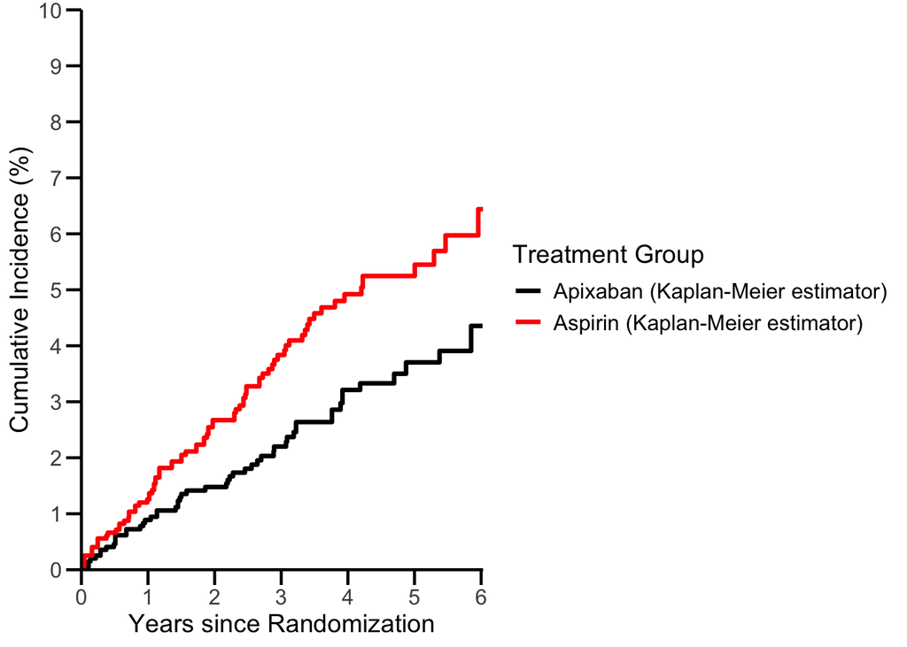

## 1.2 Log-Rank Test for Comparison

```r
text_log.rank <- survdiff(Surv(time, status) ~ treat, data=data, rho=0)
text_log.rank
```

```
## Call:
## survdiff(formula = Surv(time, status) ~ treat, data = data, rho = 0)
##
##            N Observed Expected (O-E)^2/E (O-E)^2/V
## treat=0 1997       81     65.8      3.52      6.98
## treat=1 2015       52     67.2      3.45      6.98
##
##  Chisq= 7  on 1 degrees of freedom, p= 0.008
```

- Reconstructed: p = 0.008
- Published ARTESIA: p = 0.007

## 1.3 Cox Proportional Hazards Model (cause-specific HR)

Below we estimate the cause-specific HR using the extracted data and find that it is nearly identical to the cause-specific HR reported in the trial.

```r
# Fit a Cox model to estimate HR of apixaban vs. aspirin
cox_model <- coxph(Surv(time, status == 1) ~ treat, data = data)

# Extract HR and 95% CI from model summary
hr_summary <- summary(cox_model)
hr <- hr_summary$conf.int[, "exp(coef)"]  # Hazard Ratio
hr_lower <- hr_summary$conf.int[, "lower .95"]  # Lower 95% CI
hr_upper <- hr_summary$conf.int[, "upper .95"]  # Upper 95% CI

hr_results <- data.frame(
  HR = round(hr,2),
  CI_lower = round(hr_lower,2),
  CI_upper = round(hr_upper,2)
)

print(hr_results)
```

```
##     HR CI_lower CI_upper
## 1 0.63     0.44     0.89
```

- Reconstructed: HR = 0.63 (0.44 to 0.89)
- Reported by ARTESIA: HR = 0.63 (0.45 to 0.88)

# 2 Prepare Data for Competing Risk Analysis

The extracted event-level data identifies the time points when outcome events occur (i.e., status == 1) and when censoring events occur (i.e., status == 0). According to the primary publication, the following event types were censored: death, 24-hr AF, drop out, end of study. For this analysis we want to estimate the absolute risk reduction when death and 24 hour AF events are treated as competing events. Since we do not know the specific times when competing events (death, 24 hr AF) occurred, we probabilistically re-categorized censoring event as competing events, using the steps below.

## 2.1 Bin Follow-Up Time into Annual Intervals

We estimate the probability that an event that was recorded as a censoring event was actually a competing event on the year-level. That is, we collapse follow-up times into one-year bins (e.g., year 1, 2, …, 6). This avoids the issue of sparse censoring events at exact time points.

```r
# Function to bin each discrete time point into 1 year intervals. max_time: upper bound of follow-up (default 6 years)
bin_time <- function(data, max_time = 6, interval = 1) {
  data %>%
    mutate(bin_time = ceiling(pmin(time, max_time) / interval))
}

data_bin <- bin_time(data)
```

## 2.2 Summarize Censoring and Outcome Events by Year & Treatment

- status == 0 → censored: due to death, 24 hr AF, lost to follow-up, study end before a primary outcome event
- status == 1 → primary event occurred: stroke or systemic embolism
- bin_time (1–6) → Represents the year of follow-up: e.g., bin_time == 2 means Year 2 This preprocessing is essential before probabilistically reclassifying censored cases into competing risks in the next step of the analysis.

### 2.2.1 Count censored events (status == 0) by year and treatment

```r
censored <- data_bin %>%
  filter(status == 0) %>%
  group_by(bin_time, treat) %>%
  summarise(count = n(), .groups = "drop")

censored %>% gt() %>%  cols_label(
    bin_time = "Study year",
    treat = "Treatment arm (1 = apix, 0 = asa)",
    count = "Count of censoring events"
  )
```

| Study year | Treatment arm (1 = apix, 0 = asa) | Count of censoring events |
| --- | --- | --- |
| 1 | 0 | 196 |
| 1 | 1 | 212 |
| 2 | 0 | 214 |
| 2 | 1 | 218 |
| 3 | 0 | 403 |
| 3 | 1 | 391 |
| 4 | 0 | 329 |
| 4 | 1 | 327 |
| 5 | 0 | 310 |
| 5 | 1 | 343 |
| 6 | 0 | 464 |
| 6 | 1 | 472 |

### 2.2.2 Count primary outcome events (status == 1) by year and treatment

```r
event <- data_bin %>%
  filter(status == 1) %>%
  group_by(bin_time, treat) %>%
  summarise(count = n(), .groups = "drop")

event %>% gt() %>%  cols_label(
    bin_time = "Study year",
    treat = "Treatment arm (1 = apix, 0 = asa)",
    count = "Count of primary outcome events"
  )
```

| Study year | Treatment arm (1 = apix, 0 = asa) | Count of primary outcome events |
| --- | --- | --- |
| 1 | 0 | 24 |
| 1 | 1 | 17 |
| 2 | 0 | 24 |
| 2 | 1 | 10 |
| 3 | 0 | 16 |
| 3 | 1 | 10 |
| 4 | 0 | 11 |
| 4 | 1 | 10 |
| 5 | 0 | 2 |
| 5 | 1 | 3 |
| 6 | 0 | 4 |
| 6 | 1 | 2 |

## 2.3 Estimate Number of Competing Events from Trial Summary Statistics

### 2.3.1 Create year-level risk of death and 24 hrs AF

- Start with the number of participants at risk each year.
- Estimate expected deaths and 24 hr AF events in a given year
- The number of competing evnets events (deaths and 24 hrs events) in a given divided by the number of all censoring events in that year gives the probability that censoring event should be recoded as a competing event.

```r
# Trial-reported counts from ARTESIA for each arm (N Engl J Med 2024;390:107-17)
asa_enrolled <- 1997  # aspirin arm N
asa_deaths <- 341     # deaths in aspirin arm
asa_af <- 476         # >24h AF in aspirin arm

apix_enrolled <- 2015 # apixaban arm N
apix_deaths <- 362    # Deaths in apixaban arm
apix_af <- 490        # >24h AF in apixaban arm

##Total the number at risk starting each year. These numbers are from the Figure 1
asa_at_risk <- c(1997, 1777, 1539, 1120, 780, 468)
apix_at_risk <- c(2015, 1786, 1558, 1157, 820, 474)

## censoring events extracted from inverse KM curve
censoring_asa <- censored %>% filter(treat==0) %>% select(count) %>% rename(censoring = count)
censoring_apix <- censored %>% filter(treat==1) %>% select(count) %>% rename(censoring = count)

## outcome events extracted from inverse KM curve
events_asa <- event %>% filter(treat==0) %>% select(count) %>% rename(outcome_events = count)
events_apix <- event %>% filter(treat==1) %>% select(count) %>% rename(outcome_events = count)

## create table for aspirin group
asa_df <- tibble(
  year = paste0(0:5, "-", 1:6),
  at_risk = asa_at_risk,
  )

asa_df <- bind_cols(asa_df, censoring_asa, events_asa)

##create table for apixaban group
apix_df <- tibble(
  year = paste0(0:5, "-", 1:6),
  at_risk = apix_at_risk,
  )

apix_df <- bind_cols(apix_df, censoring_apix, events_apix)

##calculate probability of 24 hr AF assuming uniform annual risk
asa_total_at_risk  <- sum(asa_at_risk)
apix_total_at_risk <- sum(apix_at_risk)

asa_df$uniform_af_rate <- asa_af/asa_total_at_risk
apix_df$uniform_af_rate <- apix_af/apix_total_at_risk

##calculate probability of death assuming a Gompertz distribution with a beta or c of 0.12
##estimate the number of competing events
##estimate the probability that an observed censoring event in the extracted data is a competing event
##first for ASA arm and then for apix arm
c = 1.12
weights = c(c^0, c^1, c^2, c^3, c^4, c^5)

###asprin arm
asa_df$weights = weights
asa_df$base_death_rate = asa_deaths / sum(asa_at_risk * weights) #base death rate account for increasing mortality rate over time
asa_df <- mutate(
  asa_df,
  weighted_death_prob = base_death_rate * weights, # weighted probability of death
  est_deaths = at_risk * weighted_death_prob, #estimated deaths
  est_AF = at_risk * uniform_af_rate, #estimated 24 hr AF events
  competing_events = est_deaths + est_AF, #estimated total number of competing events
  revised_censoring = censoring - competing_events, #new number of censoring events accounting for competing events
  prob_competing_events = 1 - revised_censoring / censoring #probability that an observed censoring event was a competing event
  )

###apixaban arm
apix_df$weights = weights
apix_df$base_death_rate = apix_deaths / sum(apix_at_risk * weights)
apix_df <- mutate(
  apix_df,
  weighted_death_prob = base_death_rate * weights,
  est_deaths = at_risk * weighted_death_prob,
  est_AF = at_risk * uniform_af_rate,
  competing_events = est_deaths + est_AF,
  revised_censoring = censoring - competing_events,
  prob_competing_events = 1 - revised_censoring / censoring
  )
```

**Aspirin arm**

| **Year (A)** | **Number at risk (B)*** | **Total censoring events (C)*** | **Primary outcome count (D)*** | **Death rate if the rate is uniform (E)**† | **Death rate weighted by Gompertz distribution (F)** | **Estimated number of death (G = B*F)** | **24hr AF event rate, uniform (H)**‡ | **Estimated number of 24hr AF events (I = B*H)** | **Total number of competing events (J = G+I)** | **Revised number of censoring events (K = C-J)** | **Probability that an original coded censoring event was a competing event (L = 1-K/C)** |
| --- | --- | --- | --- | --- | --- | --- | --- | --- | --- | --- | --- |
| 0-1 | 1997 | 196 | 24 | 3.57% | 3.57% | 71 | 6.20% | 124 | 195 | 1 | 99.5% |
| 1-2 | 1777 | 214 | 24 | 3.57% | 4.00% | 71 | 6.20% | 110 | 181 | 33 | 84.7% |
| 2-3 | 1539 | 403 | 16 | 3.57% | 4.48% | 69 | 6.20% | 95 | 164 | 239 | 40.8% |
| 3-4 | 1120 | 329 | 11 | 3.57% | 5.02% | 56 | 6.20% | 69 | 126 | 203 | 38.2% |
| 4-5 | 780 | 310 | 2 | 3.57% | 5.62% | 44 | 6.20% | 48 | 92 | 218 | 29.7% |
| 5-6 | 468 | 464 | 4 | 3.57% | 6.30% | 29 | 6.20% | 29 | 58 | 406 | 12.6% |

* Values from extracted event-level data from inverse-KM curve  
† Value based on published mortality rate by arm  
‡ Value based on published 24-hr AF event rate by arm

**Apixaban arm**

| **Year (A)** | **Number at risk (B)*** | **Total censoring events (C)*** | **Primary outcome count (D)*** | **Death rate if the rate is uniform (E)**† | **Death rate weighted by Gompertz distribution (F)** | **Estimated number of death (G = B*F)** | **24hr AF event rate, uniform (H)**‡ | **Estimated number of 24hr AF events (I = B*H)** | **Total number of competing events (J = G+I)** | **Revised number of censoring events (K = C-J)** | **Probability that an original coded censoring event was a competing event (L = 1-K/C)** |
| --- | --- | --- | --- | --- | --- | --- | --- | --- | --- | --- | --- |
| 0-1 | 2015 | 212 | 17 | 3.72% | 3.72% | 75 | 6.27% | 126 | 201 | 11 | 95.0% |
| 1-2 | 1786 | 218 | 10 | 3.72% | 4.17% | 74 | 6.27% | 112 | 187 | 31 | 85.6% |
| 2-3 | 1558 | 391 | 10 | 3.72% | 4.67% | 73 | 6.27% | 98 | 171 | 220 | 43.6% |
| 3-4 | 1157 | 327 | 10 | 3.72% | 5.23% | 61 | 6.27% | 73 | 133 | 194 | 40.7% |
| 4-5 | 820 | 343 | 3 | 3.72% | 5.86% | 48 | 6.27% | 51 | 99 | 244 | 29.0% |
| 5-6 | 474 | 472 | 2 | 3.72% | 6.56% | 31 | 6.27% | 30 | 61 | 411 | 12.9% |

* Values from extracted event-level data from inverse-KM curve  
† Value based on published mortality rate by arm  
‡ Value based on published 24-hr AF event rate by arm

### 2.3.2 Create Function ‘modify_fstatus()’ to Reclassifies a Portion of Censored Events as Competing Events

```r
competing_events_count = c(round(asa_df$competing_events),round(apix_df$competing_events))

# Function to reclassify fstatus
modify_fstatus <- function(data_bin) {
  data_bin <- data_bin %>%
    mutate(fstatus = status)

  # number of cases to switch per group and bin_time
  switch_counts <- data.frame(
    treat = rep(0:1, each = 6),
    bin_time = rep(1:6, 2),
    switch_n = competing_events_count
  )

  # reclassify fstatus randomly
  for (i in 1:nrow(switch_counts)) {
    subset_indices <- which(data_bin$treat == switch_counts$treat[i] &
                              data_bin$bin_time == switch_counts$bin_time[i] &
                              data_bin$fstatus == 0)

    if (length(subset_indices) >= switch_counts$switch_n[i]) {
      switch_indices <- sample(subset_indices, switch_counts$switch_n[i])
      data_bin$fstatus[switch_indices] <- 2
    }
  }

  return(data_bin)
}
```

# 3 Main Analysis

## 3.1 Plotting Simulated CIF Curves Using Fine–Gray Subdistribution Hazard Model

### 3.1.1 Step 1: create a CIF function

```r
# function to compute CIF using the 'cuminc' function
compute_cif <- function(data_bin) {
  cif <- cuminc(ftime = data_bin$time, fstatus = data_bin$fstatus, group = data_bin$treat)
  return(cif)
}
```

### 3.1.2 Step 2: Run 1000 simulations probabalistically reclassifying competing events

```r
# Loop over simulations
num_simulations <- 1000
set.seed(51)

# Pre-allocate storage lists
cif_treat_0_list <- list()
cif_treat_1_list <- list()

# Pre-allocate vectors to store simulation results
risk_diffs6      <- numeric(num_simulations)
se_risk_diffs6   <- numeric(num_simulations)

cuminc_treat1_6  <- numeric(num_simulations)
cuminc_treat0_6  <- numeric(num_simulations)
se_cuminc_treat1 <- numeric(num_simulations)
se_cuminc_treat0 <- numeric(num_simulations)


# Run simulations
for (i in 1:num_simulations) {
  # create modified dataset
  modified_data_bin <- modify_fstatus(data_bin)

  # compute CIF
  cif <- compute_cif(modified_data_bin)

  # store CIF results for each treatment group
  cif_treat_0_list[[i]] <- data.frame(
    time = cif$`0 1`$time,
    cif = cif$`0 1`$est,
    simulation = i
  )
  cif_treat_1_list[[i]] <- data.frame(
    time = cif$`1 1`$time,
    cif = cif$`1 1`$est,
    simulation = i
  )

    # extract 6-year CIF estimates for both groups
  cif_t0 <- cif$`0 1`$est[which.min(abs(cif$`0 1`$time - 6))]
  cif_t1 <- cif$`1 1`$est[which.min(abs(cif$`1 1`$time - 6))]

  # calculate RD and its standard error
  rd <- cif_t1 - cif_t0
  se_rd <- sqrt(
    cif_t1 * (1 - cif_t1) / sum(modified_data_bin$treat == 1) +
    cif_t0 * (1 - cif_t0) / sum(modified_data_bin$treat == 0)
  )

  # Compute SEs for individual CIF estimates
  se1 <- sqrt(cif_t1 * (1 - cif_t1) / sum(modified_data_bin$treat == 1))
  se0 <- sqrt(cif_t0 * (1 - cif_t0) / sum(modified_data_bin$treat == 0))

  # Store results from current iteration
  risk_diffs6[i]      <- rd
  se_risk_diffs6[i]   <- se_rd
  cuminc_treat1_6[i]  <- cif_t1
  cuminc_treat0_6[i]  <- cif_t0
  se_cuminc_treat1[i] <- se1
  se_cuminc_treat0[i] <- se0
}
```

### 3.1.3 Step 3: Combine simulation results and compute confidence intervals

```r
# Combine CIF data from all simulations
cif_treat_0_all <- do.call(rbind, cif_treat_0_list)
cif_treat_1_all <- do.call(rbind, cif_treat_1_list)

# Summarize percentiles for each time point by treatment group
percentiles_cif_treat_0 <- cif_treat_0_all %>%
  group_by(time) %>%
  summarise(
    p2.5 = quantile(cif, 0.025, na.rm = TRUE),
    p50 = quantile(cif, 0.5, na.rm = TRUE),
    p97.5 = quantile(cif, 0.975, na.rm = TRUE)
  ) %>%
  mutate(group = "Aspirin (Aalen-Johansen estimator)")

percentiles_cif_treat_1 <- cif_treat_1_all %>%
  group_by(time) %>%
  summarise(
    p2.5 = quantile(cif, 0.025, na.rm = TRUE),
    p50 = quantile(cif, 0.5, na.rm = TRUE),
    p97.5 = quantile(cif, 0.975, na.rm = TRUE)
  ) %>%
  mutate(group = "Apixaban (Aalen-Johansen estimator)")

# Combine both treatment groups into one dataset
percentiles_cif_data <- bind_rows(percentiles_cif_treat_0, percentiles_cif_treat_1)
```

## 3.2 Risk Difference at 6 Years Using Kaplan-Meier analysis (death and 24-hr AF events treated as censoring events)

- Estimate the 6-year cumulative incidence of the primary event (stroke/systemic embolism)
- For each treatment arm, and compute the Risk Difference (RD) with 95% Confidence Interval (CI), # Using a Kaplan-Meier analysis (deaths and 24-hr AF events are censored)

**Absolute risk redcution at 6-years treating death and 24hr AF events as censoring events**

| Group | Estimate | Standard Error | 95% CI Lower | 95% CI Upper |
| --- | --- | --- | --- | --- |
| Absolute risk reduction | −2.09% | 1.15% | −4.34% | 0.17% |
| Apixaban arm | 4.35% | 0.74% | 2.90% | 5.81% |
| Aspirin arm | 6.44% | 0.88% | 4.72% | 8.16% |

- This analysis treats death and AF progression as censoring events, mirroring the original ARTESIA design.
- RD estimates the absolute treatment benefit of apixaban over aspirin at 6 years.

## 3.3 Risk Difference at 6 Years Using Competing Risks Simulations

**Absolute risk reduction at 6-years treating death and 24hr AF events as competing events**

| Group | Estimate | Standard Error | 95% CI Lower | 95% CI Upper |
| --- | --- | --- | --- | --- |
| Absolute risk reduction | −1.68% | 0.62% | −2.89% | −0.46% |
| Apixaban arm | 3.18% | 0.39% | 2.41% | 3.94% |
| Aspirin arm | 4.86% | 0.48% | 3.91% | 5.80% |

## 3.4 Plot

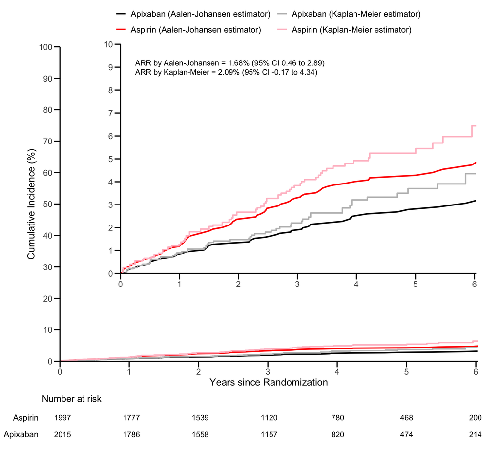